# Processing Flight Data

This vignette will show you how the telprep package can be used to automatically process data from telemetry flights. The program is designed to read in raw txt files, filter out erroneous signals, determine the living status of fish, and create some pretty pictures. This tutorial highlights the general workflow of the program. For a finer scale description of the program functionalities, see the help files for the following functions: read.flight.data, channels.merge, replace.date, combine.data, get.date.bins, get.best.locations, flag.dead.fish, plot.locations, and add.to.database.

### Program Workflow:

- Step 1 – Import geographic data
- Step 2 – Read raw detection data into R
- Step 3 – If channels or dates were misprogrammed, make corrections
- Step 4 – Combine all of the raw data into a single data.frame
- Step 5 – Flag for erroneous signals and determine the living status fish
- Step 6 – Determine the living status of the fish
- Step 7 – Create some pretty pictures
- Step 8 – Add the data to a pre-existing database

### Step 1: Import geographic data

In order to use the telprep package, you must first import a SpatialLinesDataFrame representation of the river system into R. The following lines of code are used to import the shapefile (names example.shp) as a SpatialLinesDataFrame object (please see the sp package for help):

```r
setwd("D:/Jordy/telprep/telprep/data/sf")
sldf <- readOGR("example.shp")
```

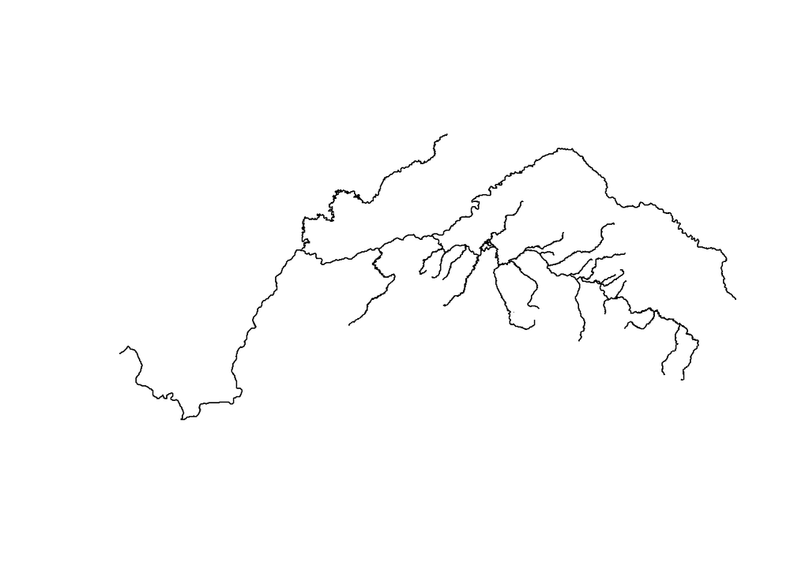

```r
plot(sldf)
```

### Step 2 – Read raw detection data into R

```r
directory <- "C:/Users/19708/Desktop/data/"
crs_data <- "+proj=longlat +datum=NAD83 +no_defs +ellps=GRS80 +towgs84=0,0,0"
crs_sldf <- "+proj=aea +lat_1=55 +lat_2=65 +lat_0=50 +lon_0=-154 +x_0=0 +y_0=0 +datum=NAD83 +units=m +no_defs +ellps=GRS80 +towgs84=0,0,0"
raw_data <- read.flight.data(directory, crs_data, crs_sldf)
```

All of the raw data is now stored in the variable raw_data.

Structurally, raw_data is a list of data.frames. To see how the data is organized internally, run

```r
names(raw_data)
```

```
##  [1] "tburb_f1_1-26-19-BELLY.TXT"
##  [2] "tburb_f1_1-26-19-WING.TXT"
##  [3] "tburb_f1_1-27-19-BELLY.TXT"
##  [4] "tburb_f1_1-27-19-WING.TXT"
##  [5] "tburb_f2_2-6-19-BELLY.TXT"
##  [6] "tburb_f2_2-6-19-WING.TXT"
##  [7] "tburb_f2_2-7-19-BELLY.TXT"
##  [8] "tburb_f2_2-7-19-WING.TXT"
##  [9] "tburb_f3_5-19-19-BELLY.TXT"
## [10] "tburb_f3_5-19-19-WING.TXT"
## [11] "tburb_f3_5-20-19-BELLY.TXT"
## [12] "tburb_f3_5-20-19-WING.TXT"
## [13] "tburb_f4_July-19-BELLY.TXT"
## [14] "tburb_f4_July-19-WING.TXT"
## [15] "tburb_f5_10-17-19-BELLY.TXT"
## [16] "tburb_f5_10-17-19-WING.TXT"
## [17] "tburb_f5_10-7-19-BELLY.TXT"
## [18] "tburb_f5_10-7-19-WING.TXT"
## [19] "tburb_f6_Dec-19-BELLY.TXT"
## [20] "tburb_f6_Dec-19-WING.TXT"
## [21] "tburb_f7_Jan-20-AG-1stFL-LEFT ANTENNA-WING.TXT"
## [22] "tburb_f7_Jan-20-AG-1stFL-RIGHT ANTENNA-BELLY.TXT"
## [23] "tburb_f7_Jan-20-AG-2ndFL-LEFT ANTENNA-WING.TXT"
## [24] "tburb_f7_Jan-20-AG-2ndFL-RIGHT ANTENNA-BELLY.TXT"
## [25] "tburb_f8_Feb-20-BELLY.TXT"
## [26] "tburb_f8_Feb-20-WING.TXT"
```

The contents of “tburb_f1_1-26-19-WING.TXT” are stored in the 2nd data.frame in the list. To see these contents, run raw_data[[2]].

### Step 3 – If channels or dates were misprogrammed, make corrections

If a channel or date was misprogrammed, it needs to be corrected before combining the contents of raw_data into a single data.frame.

##### Misprogrammed Channels

The following example will show you how to fix a misprogrammed channel. In the example, we will suppose that channel 3 was misprogrammed as channel 10 in “tburb_f1_1-26-19-WING.TXT”. To peek at the data we can run

```r
head(raw_data[[2]])
```

```
##              DateTime Channel TagID Antenna Power Latitude Longitude Status
## 1 2019-01-25 14:10:48      35    80     AH0   120  1669615  296284.5 Active
## 3 2019-01-26 09:30:09      10    42     AH0   111  1659079  294940.0   Mort
## 4 2019-01-26 09:30:21      10    42     AH0   124  1658809  295528.2   Mort
## 5 2019-01-26 09:30:46      10    42     AH0   129  1658258  296710.0   Mort
## 6 2019-01-26 09:30:58      10    42     AH0    97  1657987  297312.1   Mort
## 7 2019-01-26 09:31:10      10    42     AH0    61  1657703  297917.8   Mort
```

To replace channel 10 with channel 3, the following line of code is run:

```r
raw_data[[2]] <- channels.merge(raw_data[[2]], 10, 3)
head(raw_data[[2]])
```

```
##              DateTime Channel TagID Antenna Power Latitude Longitude Status
## 1 2019-01-25 14:10:48      35    80     AH0   120  1669615  296284.5 Active
## 3 2019-01-26 09:30:09       3    42     AH0   111  1659079  294940.0   Mort
## 4 2019-01-26 09:30:21       3    42     AH0   124  1658809  295528.2   Mort
## 5 2019-01-26 09:30:46       3    42     AH0   129  1658258  296710.0   Mort
## 6 2019-01-26 09:30:58       3    42     AH0    97  1657987  297312.1   Mort
## 7 2019-01-26 09:31:10       3    42     AH0    61  1657703  297917.8   Mort
```

##### Misprogrammed Dates

This example will show you how to fix a misprogrammed date. We will suppose that a date was misprogrammed in the file “tburb_f5_10-17-19-WING.TXT” and the file “tburb_f5_10-7-19-WING.TXT”. To peek at the data, run

```r
head(raw_data[[16]])
```

```
##               DateTime Channel TagID Antenna Power Latitude Longitude Status
## 1  2003-04-25 08:14:11      40    30      A0    49  1669637  296277.2 Active
## 3  2003-04-25 08:14:21      40    26      A0    65  1669635  296276.6 Active
## 5  2003-04-25 08:14:23      40    30      A0    52  1669635  296276.8 Active
## 7  2003-04-25 08:14:24      40    25      A0    49  1669635  296276.9 Active
## 11 2003-04-25 08:14:32      40    57      A0    49  1669634  296276.8   Mort
## 12 2003-04-25 08:14:33      40    31      A0    69  1669634  296277.0 Active
```

```r
head(raw_data[[18]])
```

```
##                DateTime Channel TagID Antenna Power Latitude Longitude Status
## 649 2003-04-10 08:40:43      34    80      A0    68  1669613  296265.9 Active
## 650 2003-04-17 03:14:02      10     2      A0    62  1663926  288430.3 Active
## 651 2003-04-17 03:14:02      10     2      A0    56  1663928  288431.4 Active
## 652 2003-04-17 03:14:03      10     1      A0    61  1663931  288432.5 Active
## 653 2003-04-17 03:14:04      10     1      A0    52  1663931  288432.5 Active
## 654 2003-04-17 03:14:04      10     1      A0    44  1663931  288432.5 Active
```

If the correct flights dates were “10/17/19” and “10/7/19”, the following lines of code will make the corrections:

```r
raw_data[[16]] <- replace.date(raw_data[[16]], new_date ="10/17/19")
head(raw_data[[16]])
```

```
##               DateTime Channel TagID Antenna Power Latitude Longitude Status
## 1  2019-10-17 08:14:11      40    30      A0    49  1669637  296277.2 Active
## 3  2019-10-17 08:14:21      40    26      A0    65  1669635  296276.6 Active
## 5  2019-10-17 08:14:23      40    30      A0    52  1669635  296276.8 Active
## 7  2019-10-17 08:14:24      40    25      A0    49  1669635  296276.9 Active
## 11 2019-10-17 08:14:32      40    57      A0    49  1669634  296276.8   Mort
## 12 2019-10-17 08:14:33      40    31      A0    69  1669634  296277.0 Active
```

```r
raw_data[[18]] <- replace.date(raw_data[[18]], new_date ="10/7/19")
head(raw_data[[18]])
```

```
##                DateTime Channel TagID Antenna Power Latitude Longitude Status
## 649 2019-10-07 08:40:43      34    80      A0    68  1669613  296265.9 Active
## 650 2019-10-07 03:14:02      10     2      A0    62  1663926  288430.3 Active
## 651 2019-10-07 03:14:02      10     2      A0    56  1663928  288431.4 Active
## 652 2019-10-07 03:14:03      10     1      A0    61  1663931  288432.5 Active
## 653 2019-10-07 03:14:04      10     1      A0    52  1663931  288432.5 Active
## 654 2019-10-07 03:14:04      10     1      A0    44  1663931  288432.5 Active
```

### Step 4 – Combine all of the raw data into a single data.frame

The function combine.data combines all of the data stored in raw_data into a single data.frame.

An argument (source_vec) is provided so that the source of each txt file can be specified. The argument can be used to specify whether a receiver was located on the belly or the wing of the aircraft. Because 26 txt files were contained in the example folder (“C:/Users/19708/Desktop/data/”), a vector of length 26 is used to incode this information. To determine the source of each data.frame in raw_data, we can run names(raw_data) to assist in the construction of source_vec:

```r
names(raw_data)
```

```
##  [1] "tburb_f1_1-26-19-BELLY.TXT"
##  [2] "tburb_f1_1-26-19-WING.TXT"
##  [3] "tburb_f1_1-27-19-BELLY.TXT"
##  [4] "tburb_f1_1-27-19-WING.TXT"
##  [5] "tburb_f2_2-6-19-BELLY.TXT"
##  [6] "tburb_f2_2-6-19-WING.TXT"
##  [7] "tburb_f2_2-7-19-BELLY.TXT"
##  [8] "tburb_f2_2-7-19-WING.TXT"
##  [9] "tburb_f3_5-19-19-BELLY.TXT"
## [10] "tburb_f3_5-19-19-WING.TXT"
## [11] "tburb_f3_5-20-19-BELLY.TXT"
## [12] "tburb_f3_5-20-19-WING.TXT"
## [13] "tburb_f4_July-19-BELLY.TXT"
## [14] "tburb_f4_July-19-WING.TXT"
## [15] "tburb_f5_10-17-19-BELLY.TXT"
## [16] "tburb_f5_10-17-19-WING.TXT"
## [17] "tburb_f5_10-7-19-BELLY.TXT"
## [18] "tburb_f5_10-7-19-WING.TXT"
## [19] "tburb_f6_Dec-19-BELLY.TXT"
## [20] "tburb_f6_Dec-19-WING.TXT"
## [21] "tburb_f7_Jan-20-AG-1stFL-LEFT ANTENNA-WING.TXT"
## [22] "tburb_f7_Jan-20-AG-1stFL-RIGHT ANTENNA-BELLY.TXT"
## [23] "tburb_f7_Jan-20-AG-2ndFL-LEFT ANTENNA-WING.TXT"
## [24] "tburb_f7_Jan-20-AG-2ndFL-RIGHT ANTENNA-BELLY.TXT"
## [25] "tburb_f8_Feb-20-BELLY.TXT"
## [26] "tburb_f8_Feb-20-WING.TXT"
```

```r
source_vec <- c(rep(c("belly","wing"), 10), rep(c("wing","belly"),2), c("belly","wing"))
source_vec
```

```
##  [1] "belly" "wing"  "belly" "wing"  "belly" "wing"  "belly" "wing"  "belly"
## [10] "wing"  "belly" "wing"  "belly" "wing"  "belly" "wing"  "belly" "wing"
## [19] "belly" "wing"  "wing"  "belly" "wing"  "belly" "belly" "wing"
```

Now that the source of the data has been specified, we can use the function combine.data to combine the contents of raw_data:

```r
all_data <- combine.data(raw_data, source_vec)
head(all_data)
```

```
##                 DateTime Channel TagID Antenna Power Latitude Longitude Status
## 1100 2019-01-25 14:10:48      35    80     AH0   120  1669615  296284.5 Active
## 1    2019-01-26 09:15:01      63    19     AH0    43  1661183  289389.1 Active
## 2    2019-01-26 09:15:03      63    74     AH0    42  1661155  289470.6 Active
## 8    2019-01-26 09:15:52      63     3     AH0    46  1660300  291756.5 Active
## 16   2019-01-26 09:16:53      10    42     AH0   120  1659147  294789.3   Mort
## 19   2019-01-26 09:17:17      10    42     AH0   119  1658603  295970.1   Mort
##      Source
## 1100   wing
## 1     belly
## 2     belly
## 8     belly
## 16    belly
## 19    belly
```

#### A note for Laura:

4 files contain fish ID’s > 200 : * “tburb_f5_10-7-19-BELLY.TXT”  
* “tburb_f5_10-7-19-WING.TXT” * “tburb_f7_Jan-20-AG-2ndFL-RIGHT ANTENNA-BELLY.TXT” * “tburb_f8_Feb-20-WING.TXT”

How should this data be treated?

For now, I’m going to remove it:

```r
all_data <- all_data[all_data$TagID <= 100, ]
```

### Step 5: Flag for erroneous signals and determine the living status fish

The riverdist package is used internally for river distance and proximity related calculations. To use the functionality of this package, the SpatialLinesDataFrame object (from Step 1) must be converted into a river_network object. The functions line2network and cleanup should to make the conversion (the user is referred to the riverdist package for help).

```r
# river_net <- line2network(sp=sldf, tolerance = 500)
load("D:/Jordy/telprep/telprep/data/river-net.Rdata") # loads a pre-processed river_network object named river_net.
```

The river_network object will now be used to discard the detections that occurred away from the river system. To remove the detections that occurred more than 500 m away from a river channel and store the data in a variable called river_detects, run the following line of code:

```r
river_detects <- rm.land.detects(all_data, river_net, dist_thresh = 500)
```

```
## [1] "be patient -- this could take a few minutes"
```

The best location will now be determined using the function get.best.locations. In short, the best location is considered to be the river network location where the highest power detection occurred for each fish in each detection period. Two arguments can be used to specify the detection periods: date_bins allows the user to manually specify each detection period whereas bin_by allows the user to specify the length (in days) of the detection period. An overview of the manual approach is provided here.

To assist in the construction date_bins, we can run the following lines of code to look up and constuct a vector incoding the flight grouping:

```r
names(raw_data)
```

```
##  [1] "tburb_f1_1-26-19-BELLY.TXT"
##  [2] "tburb_f1_1-26-19-WING.TXT"
##  [3] "tburb_f1_1-27-19-BELLY.TXT"
##  [4] "tburb_f1_1-27-19-WING.TXT"
##  [5] "tburb_f2_2-6-19-BELLY.TXT"
##  [6] "tburb_f2_2-6-19-WING.TXT"
##  [7] "tburb_f2_2-7-19-BELLY.TXT"
##  [8] "tburb_f2_2-7-19-WING.TXT"
##  [9] "tburb_f3_5-19-19-BELLY.TXT"
## [10] "tburb_f3_5-19-19-WING.TXT"
## [11] "tburb_f3_5-20-19-BELLY.TXT"
## [12] "tburb_f3_5-20-19-WING.TXT"
## [13] "tburb_f4_July-19-BELLY.TXT"
## [14] "tburb_f4_July-19-WING.TXT"
## [15] "tburb_f5_10-17-19-BELLY.TXT"
## [16] "tburb_f5_10-17-19-WING.TXT"
## [17] "tburb_f5_10-7-19-BELLY.TXT"
## [18] "tburb_f5_10-7-19-WING.TXT"
## [19] "tburb_f6_Dec-19-BELLY.TXT"
## [20] "tburb_f6_Dec-19-WING.TXT"
## [21] "tburb_f7_Jan-20-AG-1stFL-LEFT ANTENNA-WING.TXT"
## [22] "tburb_f7_Jan-20-AG-1stFL-RIGHT ANTENNA-BELLY.TXT"
## [23] "tburb_f7_Jan-20-AG-2ndFL-LEFT ANTENNA-WING.TXT"
## [24] "tburb_f7_Jan-20-AG-2ndFL-RIGHT ANTENNA-BELLY.TXT"
## [25] "tburb_f8_Feb-20-BELLY.TXT"
## [26] "tburb_f8_Feb-20-WING.TXT"
```

```r
flight_group <- c(1,1,1,1,2,2,2,2,3,3,3,3,4,4,5,5,5,5,6,6,7,7,7,7,8,8)
```

We can now use the function get.date.bins to get the appropriate detection periods.

```r
date_bins <- get.date.bins(raw_data, flight_group)
date_bins
```

```
##      [,1]       [,2]
## [1,] "01/25/19" "01/27/19"
## [2,] "01/28/19" "02/07/19"
## [3,] "05/19/19" "05/24/19"
## [4,] "07/24/19" "07/27/19"
## [5,] "08/05/19" "10/17/19"
## [6,] "12/16/19" "12/18/19"
## [7,] "01/15/20" "01/21/20"
## [8,] "02/05/20" "02/08/20"
```

Now, we use the function get.best.locations to determine the best locations and flag for false detections:

```r
best_locations <- get.best.locations(river_detects, date_bins =  date_bins, bin_by=NA, n_thresh = 5, dist_max = 5, remove_flagged = T)
```

```r
head(best_locations$all_detects)
```

```
##                  DateTime Channel TagID Antenna Power Latitude Longitude Status
## 1     2019-01-26 09:15:01      63    19     AH0    43  1661183  289389.1 Active
## 2     2019-01-26 09:15:03      63    74     AH0    42  1661155  289470.6 Active
## 107   2019-01-26 09:44:04      82     2     AH0    50  1611683  381653.8 Active
## 11    2019-01-26 09:46:04       3    47     AH0   105  1630949  342889.5   Mort
## 11100 2019-01-26 09:46:04      10    47     AH0   105  1630949  342889.5   Mort
## 1610  2019-01-26 09:46:37       3    47     AH0   132  1631743  344633.0   Mort
##       Source BestSignal FlightNum    Dist Records
## 1      belly       TRUE         1   0.000       1
## 2      belly      FALSE         1 326.720       2
## 107    belly      FALSE         1 289.643       3
## 11      wing      FALSE         1   2.873       7
## 11100   wing      FALSE         1   3.408      10
## 1610    wing      FALSE         1   1.424       7
```

```r
head(best_locations$best_detects)
```

```
##                 DateTime Channel TagID Power Latitude Longitude Status Source
## 56   2019-01-26 11:01:53      35    85   162  1509129  607249.6 Active   wing
## 192  2019-01-26 11:03:04      10    83   183  1499605  620856.5 Active  belly
## 69   2019-01-26 11:14:41      35    84   152  1496047  624370.7   Mort   wing
## 74   2019-01-26 11:15:03      35    83   169  1497114  623783.5 Active   wing
## 91   2019-01-26 11:16:30       3    83   155  1500014  620401.8 Active   wing
## 1021 2019-01-26 11:17:54       3    82   171  1502974  617275.5 Active   wing
##      FlightNum Records  flag
## 56           1      11 FALSE
## 192          1      13 FALSE
## 69           1      10 FALSE
## 74           1      12 FALSE
## 91           1      11 FALSE
## 1021         1       7 FALSE
```

best_locations$all_detects adds some useful to all_data: BestSignal is the signal with the highest power in a detection period, Dist is the geodesic distance (in km) between the detection location and the associated highest power detection, FlightNum is the detection period, and Records is number of times that a fish was detected in a detection period.

### Step 6 – Determine the living status of the fish

Once the best locations have been determined, the function flag.dead.fish can be used to determine the living status of fish:

```r
best_detects <- best_locations$best_detects
flagged_fish <- flag.dead.fish(best_detects, dist_thresh = 0.5)
head(flagged_fish)
```

```
##                 DateTime Channel TagID Power Latitude Longitude Status Source
## 56   2019-01-26 11:01:53      35    85   162  1509129  607249.6 Active   wing
## 192  2019-01-26 11:03:04      10    83   183  1499605  620856.5 Active  belly
## 69   2019-01-26 11:14:41      35    84   152  1496047  624370.7   Mort   wing
## 74   2019-01-26 11:15:03      35    83   169  1497114  623783.5 Active   wing
## 91   2019-01-26 11:16:30       3    83   155  1500014  620401.8 Active   wing
## 1021 2019-01-26 11:17:54       3    82   171  1502974  617275.5 Active   wing
##      FlightNum Records  flag MoveDist MortFlag
## 56           1      11 FALSE       NA       No
## 192          1      13 FALSE       NA       No
## 69           1      10 FALSE       NA       No
## 74           1      12 FALSE       NA       No
## 91           1      11 FALSE       NA       No
## 1021         1       7 FALSE       NA       No
```

Here, a recursive algorithm is used to make the determination. Basically, if a fish moves less than dist_thresh km for all consecutive detection periods following a detection, the fish will be flagged as dead – the mortality sensors look super faulty to me so I’m not using this information. Be sure to download the latest package version as this algorithm is being modified. This update will use a Hidden Markov Model (HMM) to determine the living status of fish. The HMM will take distance and mortality sensor information into account statistically. The HMM will be used get estimates of fish survival and fish detection – I don’t think the current algoritm is particularly realistic and there’s no way of accounting for uncertainty in an ad-hoc estimate.

#### Step 7 – Create some pretty pictures

A plotting function (plot.locations) is included in the telprep package. This function is designed to be used throughout the analysis. Example of how the function can be used are provided here:

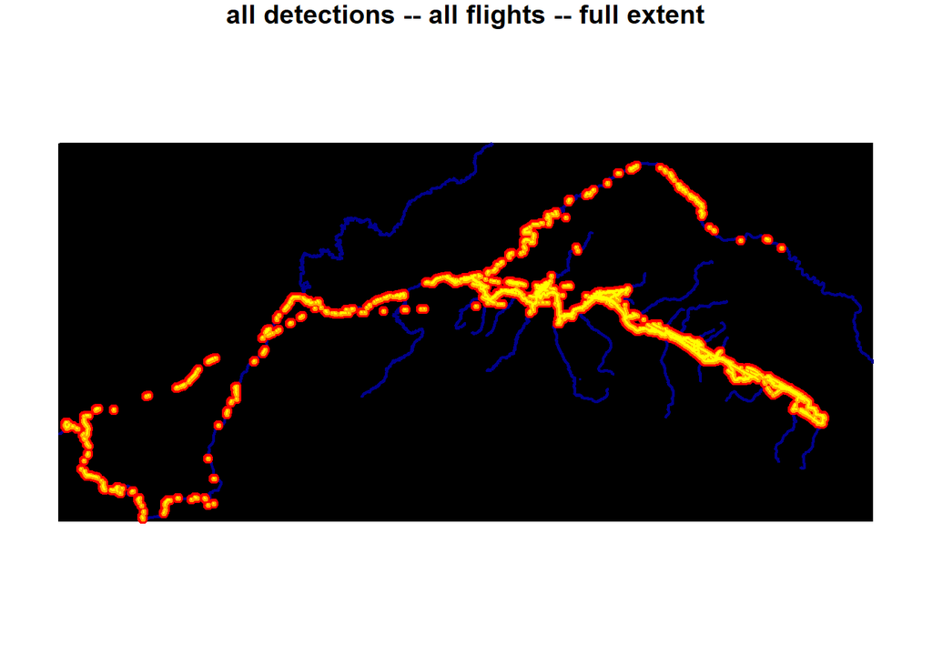

```r
# sldf <- readOGR("example.shp")
plot.locations(sldf, all_data, col_by_fish=F, main="all detections -- all flights -- full extent")
```

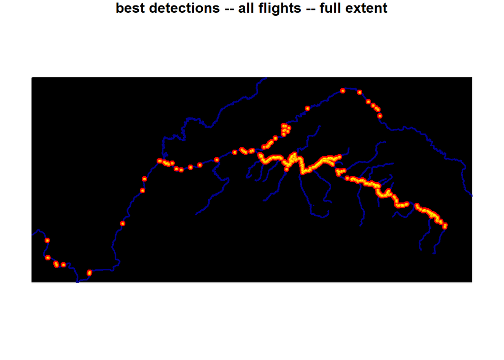

```r
plot.locations(sldf, best_detects, col_by_fish=F, main="best detections -- all flights -- full extent")
```

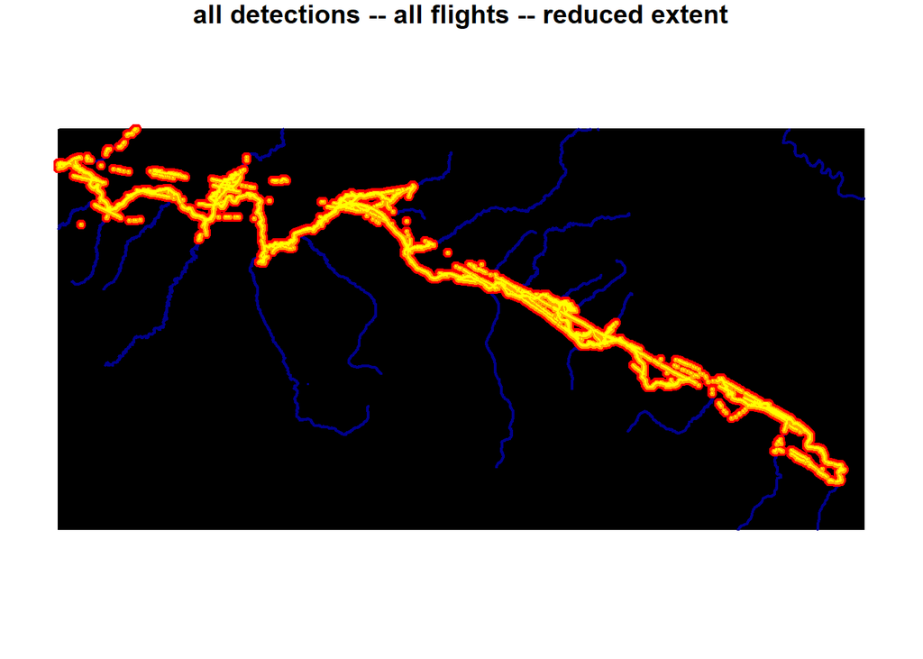

```r
# To change the extent
# can use locator() to determine new extent
sldf@bbox[1,1] <- 86343.0
sldf@bbox[1,2] <- 662656.5
sldf@bbox[2,1] <- 1428943
sldf@bbox[2,2] <- 1715734
best_detects <- best_locations$best_detects
best_detects <- best_detects[!best_detects$flag,]
plot.locations(sldf, all_data, col_by_fish=F, main="all detections -- all flights -- reduced extent")
```

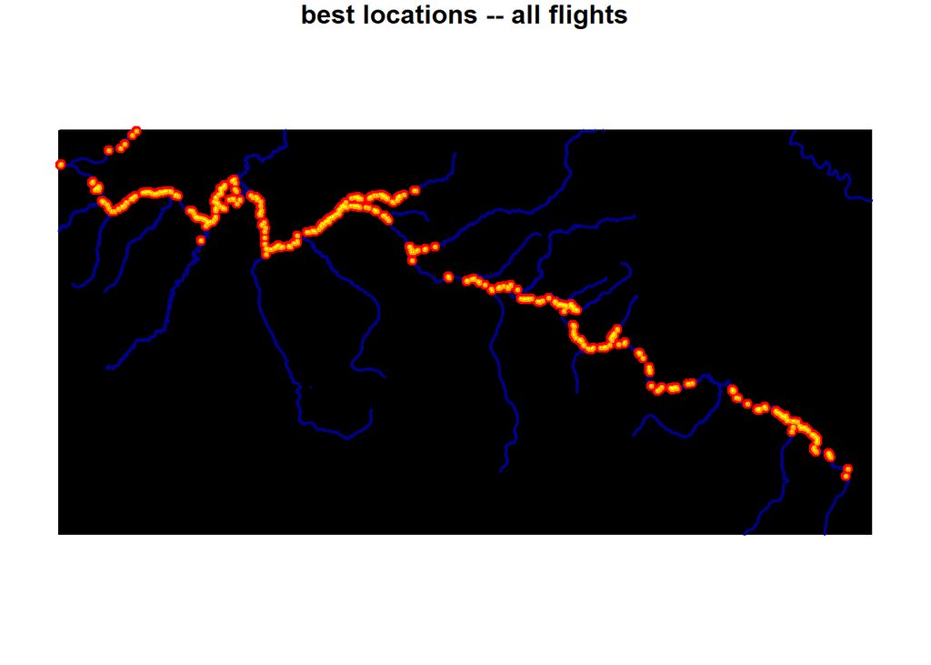

```r
plot.locations(sldf, best_detects, col_by_fish=F, main="best locations -- all flights")
```

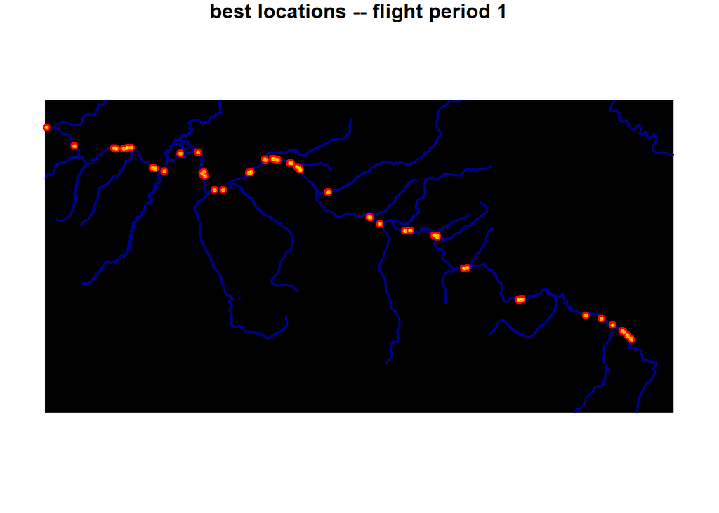

```r
a <- plot.locations(sldf, best_detects, col_by_fish=F, flight_num = 1, main="best locations -- flight period 1")
```

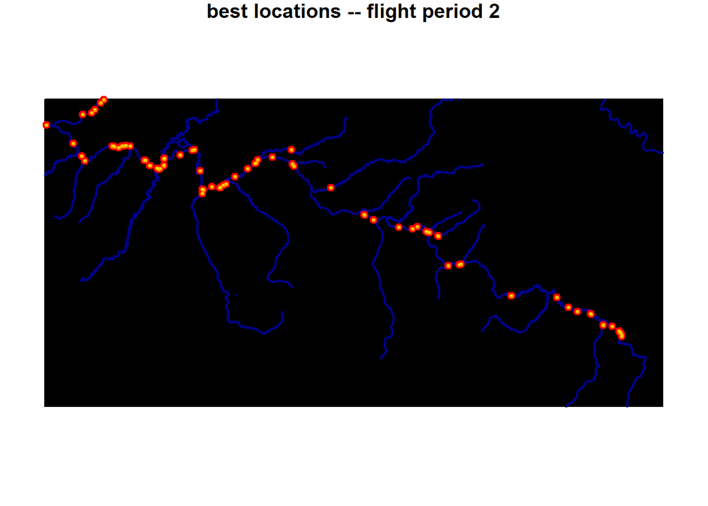

```r
b <- plot.locations(sldf, best_detects, col_by_fish=F, flight_num = 2, main="best locations -- flight period 2")
```

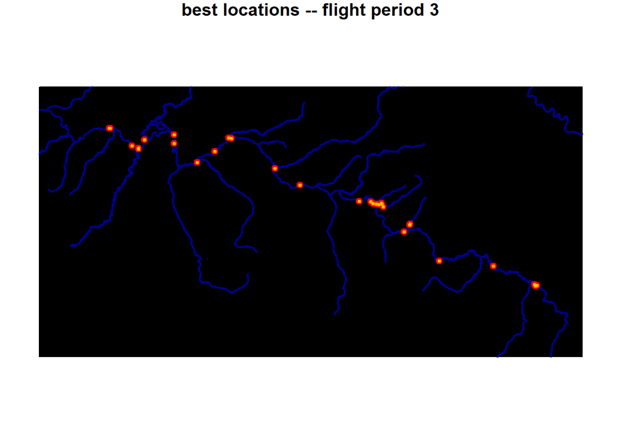

```r
c <- plot.locations(sldf, best_detects, col_by_fish=F, flight_num = 3, main="best locations -- flight period 3")
```

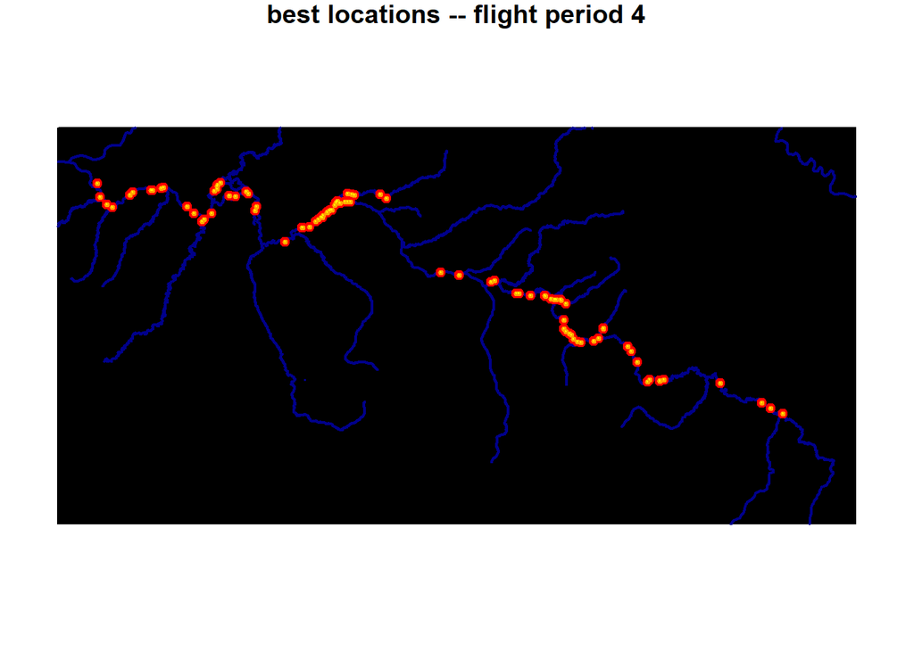

```r
d <- plot.locations(sldf, best_detects, col_by_fish=F, flight_num = 4, main="best locations -- flight period 4")
```

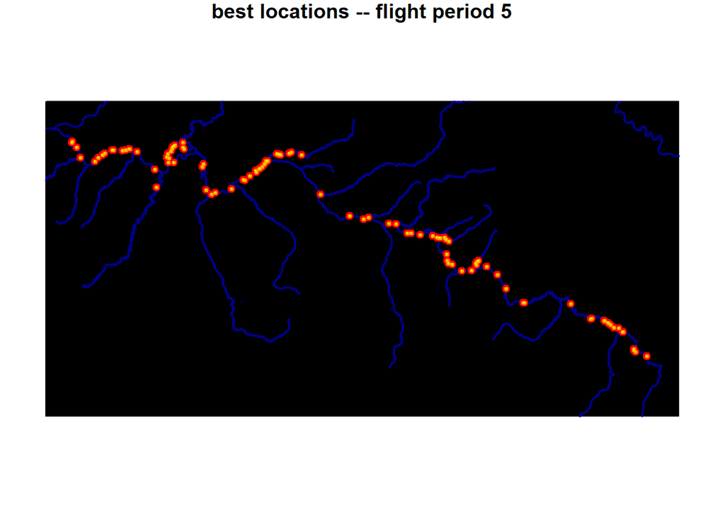

```r
e <- plot.locations(sldf, best_detects, col_by_fish=F, flight_num = 5, main="best locations -- flight period 5")
```

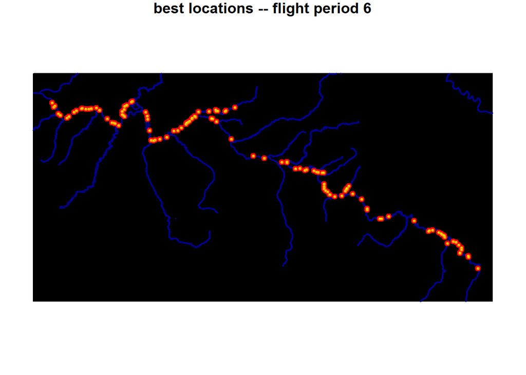

```r
f <- plot.locations(sldf, best_detects, col_by_fish=F, flight_num = 6, main="best locations -- flight period 6")
```

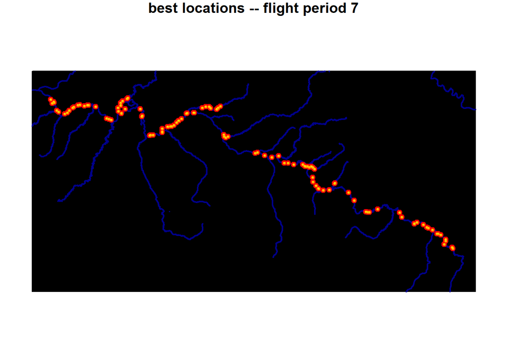

```r
g <- plot.locations(sldf, best_detects, col_by_fish=F, flight_num = 7, main="best locations -- flight period 7")
```

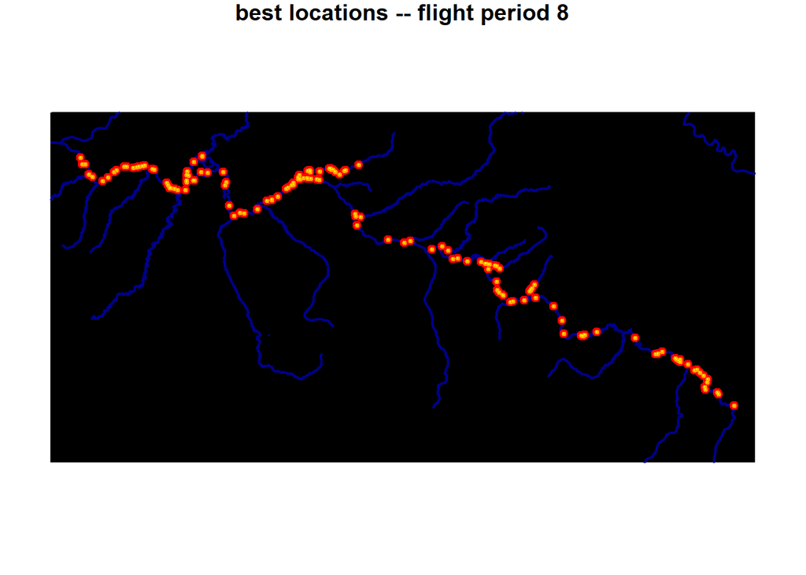

```r
h <- plot.locations(sldf, best_detects, col_by_fish=F, flight_num = 8, main="best locations -- flight period 8")
```

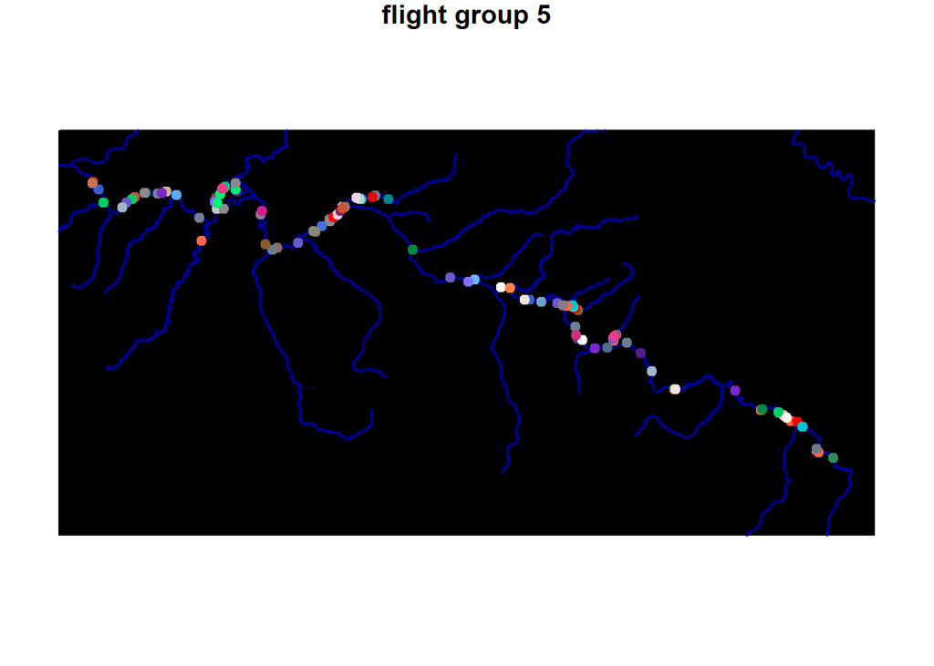

```r
# Give the fish colors and preserve the colors between flights
plot.locations(sldf, best_detects, flight_num = 5, main="flight group 5")
```

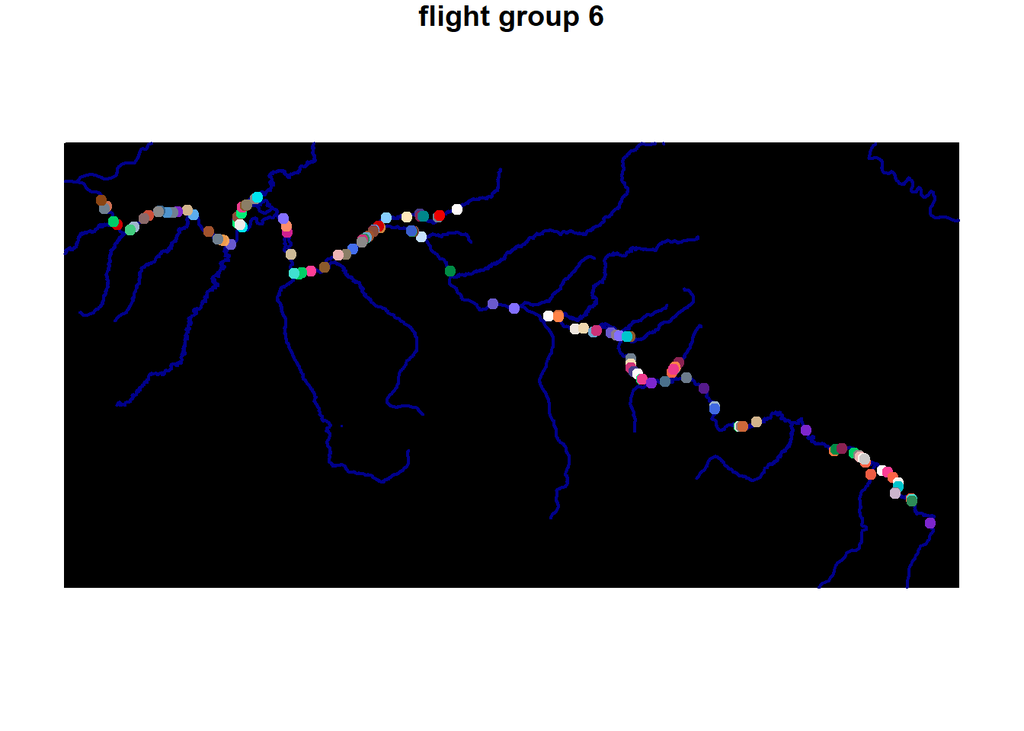

```r
plot.locations(sldf, best_detects, flight_num = 6, main="flight group 6")
```

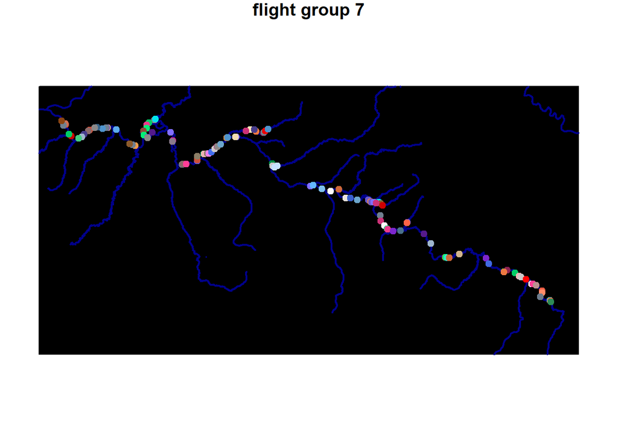

```r
plot.locations(sldf, best_detects, flight_num = 7, main="flight group 7")
```

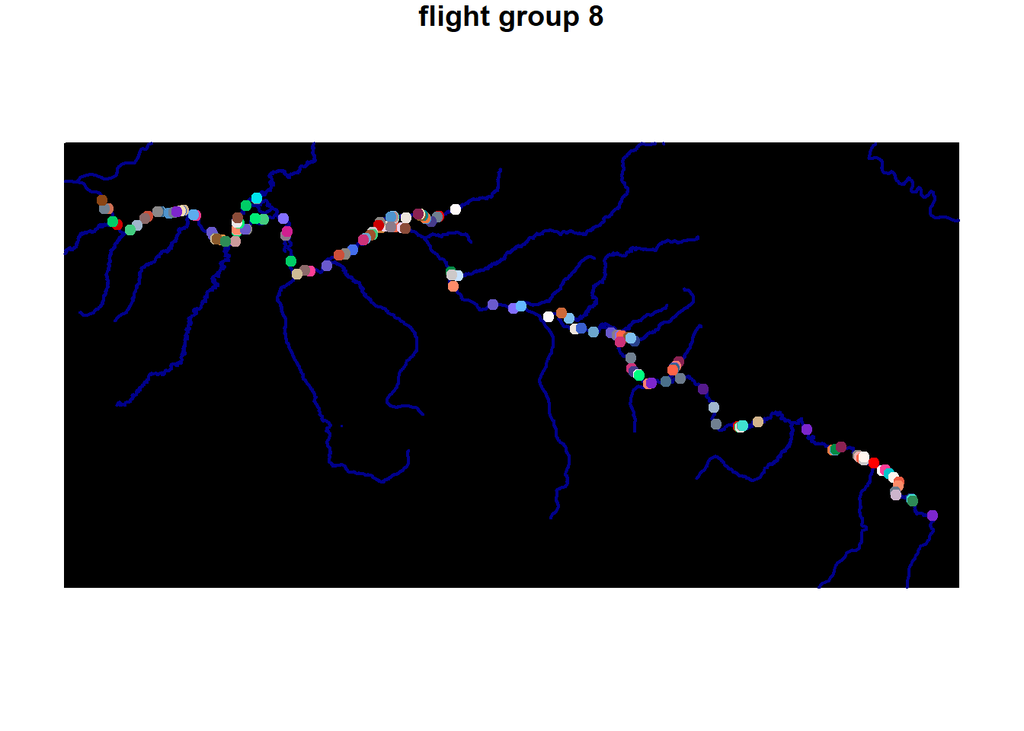

```r
plot.locations(sldf, best_detects, flight_num = 8, main="flight group 8")
```

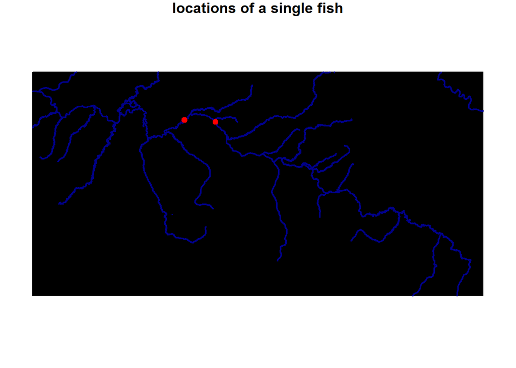

```r
# To see the path of an individual fish between flights
plot.locations(sldf, best_detects, col_by_fish=T, channel = 22, tag_id = 41, main="locations of a single fish")
```

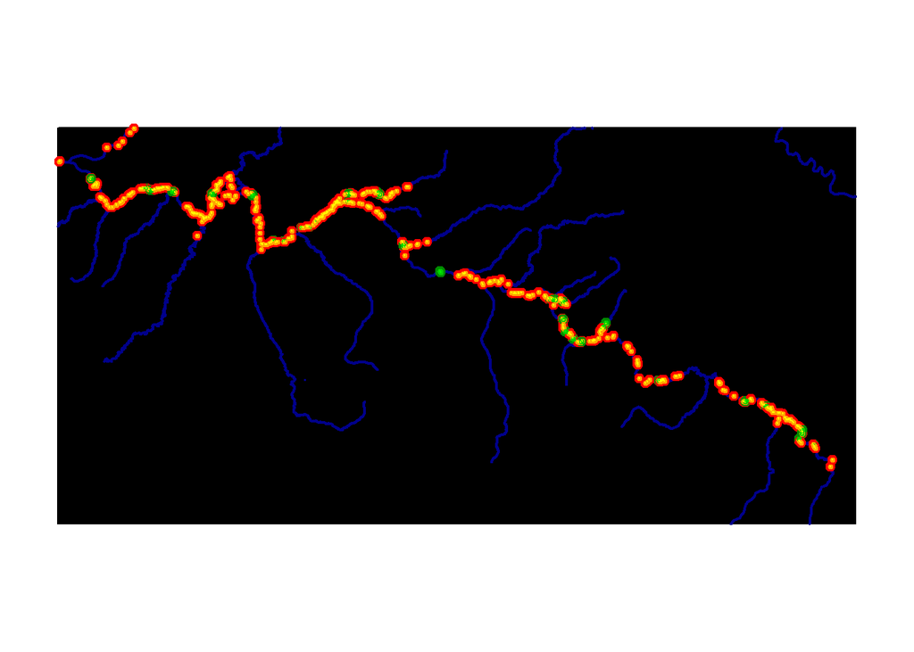

```r
# To plot live vs. dead fish
plot.locations(sldf, flagged_fish, col_by_fish = F)
```

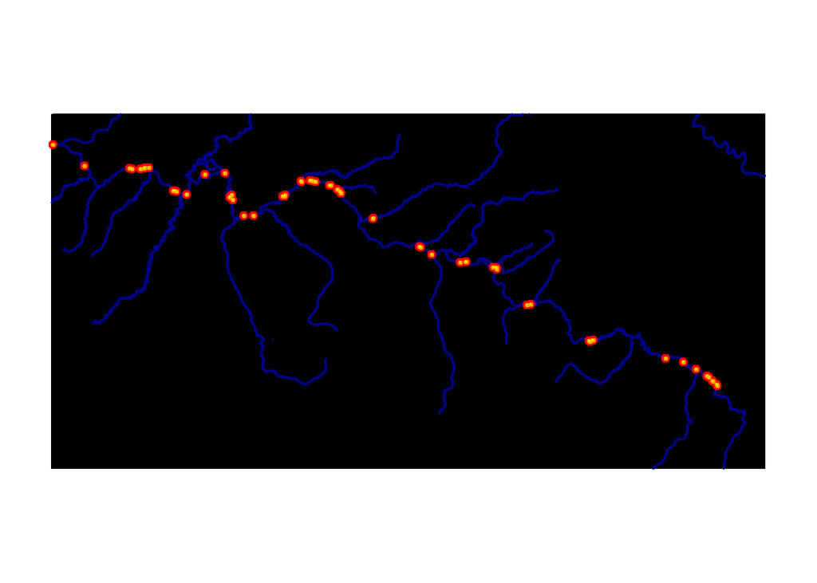

```r
plot.locations(sldf, flagged_fish, flight_num = 1,col_by_fish = F)
```

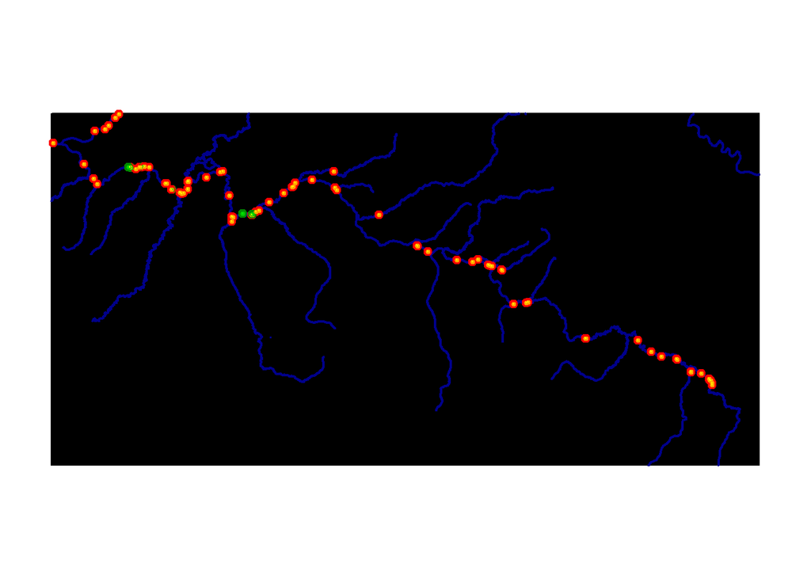

```r
plot.locations(sldf, flagged_fish, flight_num = 2,col_by_fish = F)
```

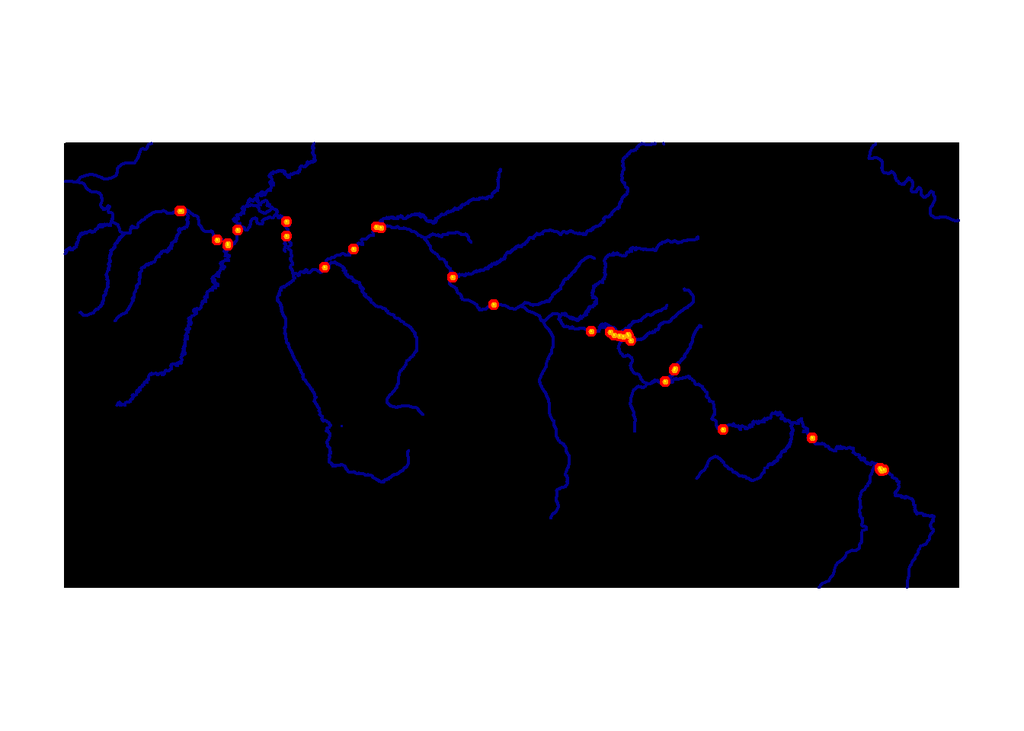

```r
plot.locations(sldf, flagged_fish, flight_num = 3,col_by_fish = F)
```

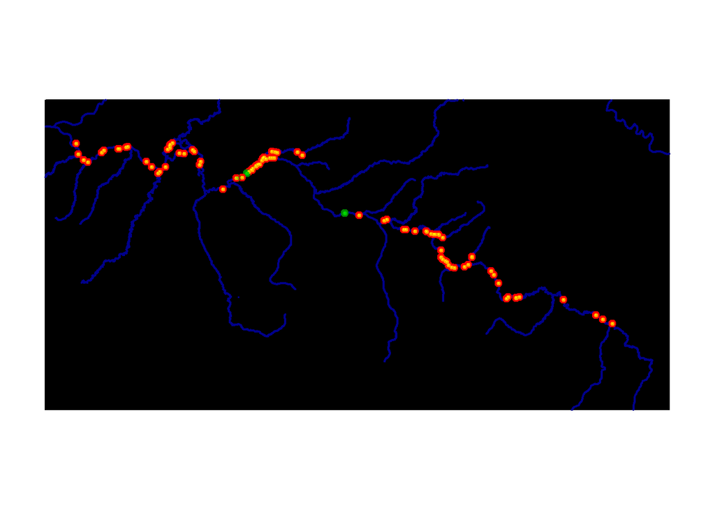

```r
plot.locations(sldf, flagged_fish, flight_num = 4,col_by_fish = F)
```

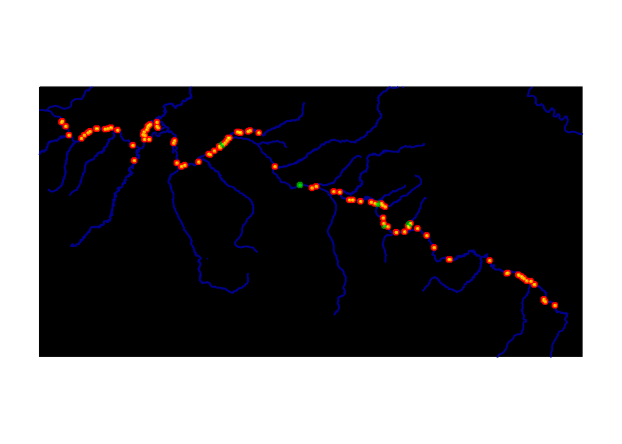

```r
plot.locations(sldf, flagged_fish, flight_num = 5,col_by_fish = F)
```

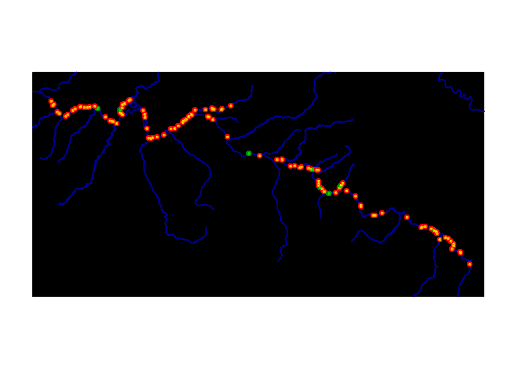

```r
plot.locations(sldf, flagged_fish, flight_num = 6,col_by_fish = F)
```

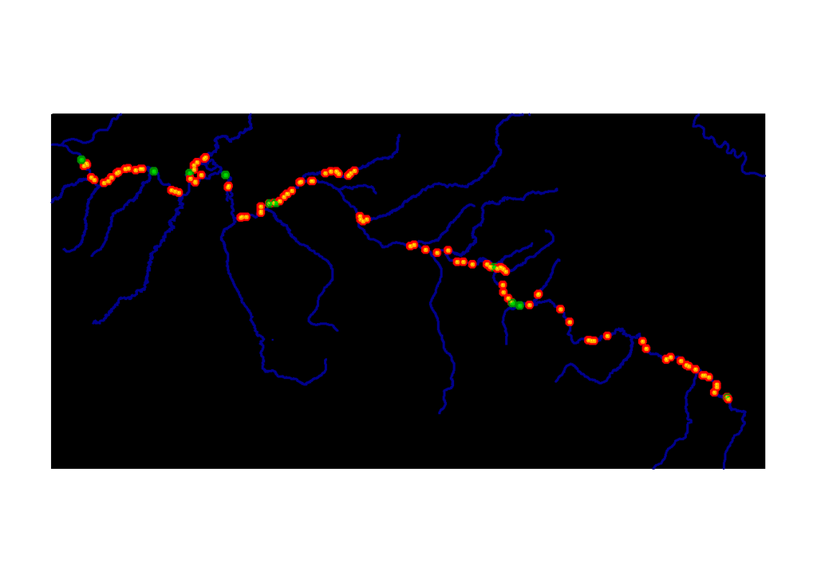

```r
plot.locations(sldf, flagged_fish, flight_num = 7,col_by_fish = F)
```

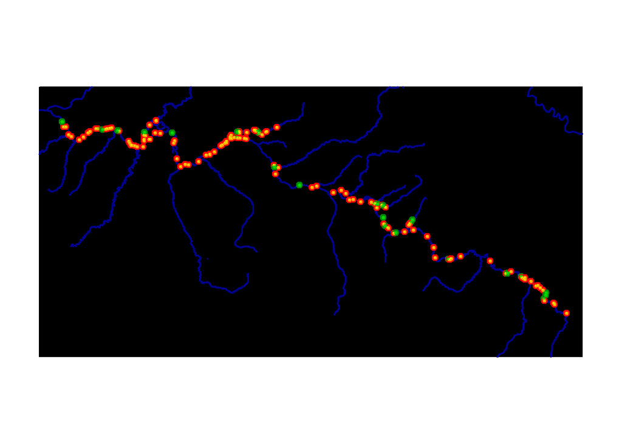

```r
plot.locations(sldf, flagged_fish, flight_num = 8,col_by_fish = F)
```

### Step 8 – Add the data to a pre-existing database

To add the results to an existing database, find the filepath of your database and run the code

```r
# filepath <- "C:/Users/19708/Desktop/database.csv"
# add.to.database(filepath, flagged_fish)
```